# Country Population Density Analysis

Allison Bailey

2/14/2020

```r
# Attach packages

library(tidyverse)
library(janitor)
library(naniar)
library(VIM)
library(skimr)
library(ggfortify)
library(here)
library(lubridate)
library(anytime)
library(ggridges)
library(viridis)
library(hrbrthemes)
library(paletteer)
library(kableExtra)
library(ggpubr)
library(sf)
library(tmap)
library(DT)
library(plotly)
library(expss)
library(ggthemes)
library(knitr)
library(gridExtra)
library(stargazer)
```

```r
# read in csv "assig1_data.csv"

country_data <- read_csv("assig1_data.csv")
```

#### 1. The data already contain a column for dN/Ndt (dNNdt; see Table 1). However, in class and section we went over how to calculate it. This first task has two components:

##### a. Describe how annual populaiton data are used to calculate dN/Ndt . (5 pts)

There are two types of population growth in the environment. The first is exponential growth, where there resources are unlimited (density-independent growth). The second is logistical growth, where resources are limited (density-dependent growth).

To project annual population growth rate with population density data, you can use the formula *ln Nt - ln No/t = r* which also remember that r = dN/Ndt.

Reminder: Nt = No e^rt where Nt = population size at time t; No = original population size, r = intrinsic rate of increase and t = time

##### b. Calculate dN/Ndt for each country for the period from 1963 to 1964. Report your results in a table that shows one row per country, with one column for the value we gave you and other column for the value you calculated.

```r
# Calculate the dN/Ndt for each country from 1963 to 1964 for each country.

country_rate <- country_data %>%
  filter(year == "1963" | year == "1964")

# First, let's start with Argentina

Argentina <- (log(x = 22020001) - log(x = 21690001))/1
# Answer: 0.0151


# Now calcuate Canada

Canada <-  (log(x = 19309001) - log(x = 18965001))/1
# Answer: 0.018

# Now calculate China

China <-  (log(x = 703333001) - log(x = 687913001))/1
# Answer: 0.022

# Now calculate India

India <-  (log(x = 486639001) - log(x = 476632001))/1
# Answer: 0.021

# Now calculate Kenya

Kenya <-  (log(x = 9198001) - log(x = 8906001))/1

# Answer: 0.032
```

```r
# Now make a table that shows the different countries dN/Ndt compared to what was given

country_table <- matrix(c(0.0151,0.0065, 0.018, 0.00786, 0.022, 0.01034,0.021,0.0099, 0.032, 0.013940849),ncol=2,byrow=TRUE)
colnames(country_table) <- c("New dN/Ndt","Given dN/Ndt")
rownames(country_table) <- c("Argentina","Canada","China", "India", "Kenya")
country_table_final <- as.table(country_table)


kable(country_table_final, col.names = c("New dN/Ndt","Given dN/Ndt"),
      caption = "***Figure 1.** The table below displays the rate of population change (dN/Ndt) between raw calculation with population data and data provided*") %>%
  kable_styling(bootstrap_options = "striped") %>%
  add_header_above(c("Rate of Population Change from 1963 to 1964" = 3))
```

**Figure 1.** The table below displays the rate of population change (dN/Ndt) between raw calculation with population data and data provided

| Rate of Population Change from 1963 to 1964 | Rate of Population Change from 1963 to 1964 New dN/Ndt | Rate of Population Change from 1963 to 1964 Given dN/Ndt |
| --- | --- | --- |
| Argentina | 0.0151 | 0.0065000 |
| Canada | 0.0180 | 0.0078600 |
| China | 0.0220 | 0.0103400 |
| India | 0.0210 | 0.0099000 |
| Kenya | 0.0320 | 0.0139408 |

##### How does your result compare to the values for dN/Ndt in the data table? (5 pts)

The dN/Ndt values I calculated based off population data were based on an exponental growth model where resources were NOT limited. So the intrinsic growth rate, r, was much higher than the dN/Ndt values given in the data set.

#### 2) Graph dN/Ndt vs Nt

##### a) In class we showed what the plot of dN/Ndt versus population density should look like. For each country,plot dN/Ndt vs Nt. (5 pts)

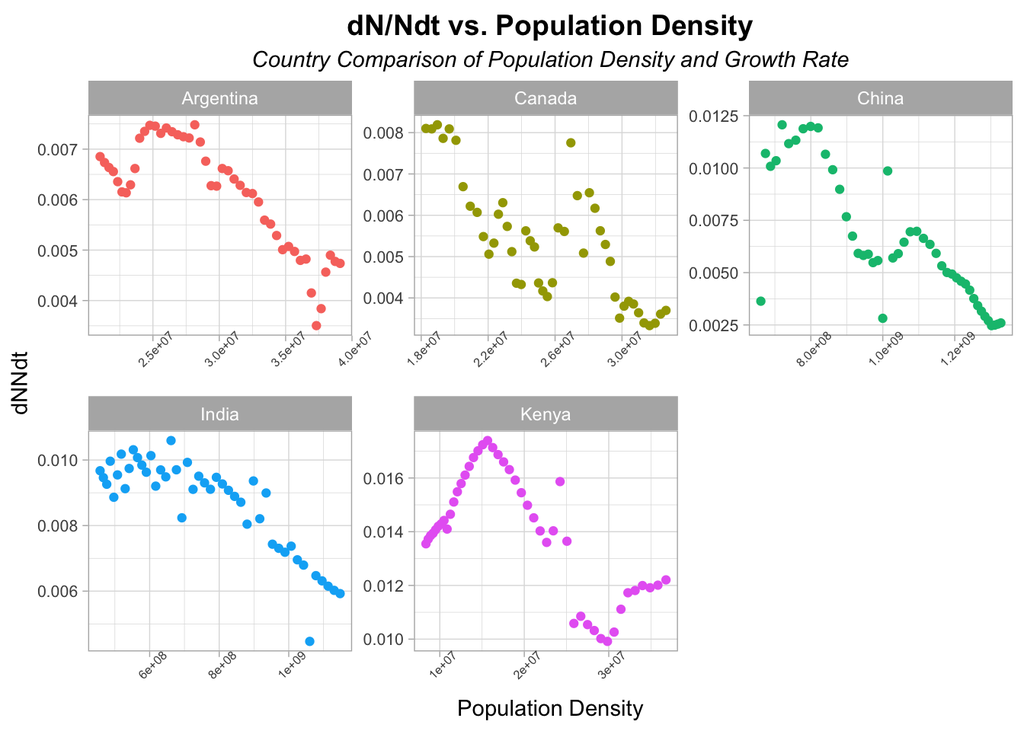

```r
country_jitter <- ggplot(country_data, aes(x = population, y = dNNdt)) +
  geom_point(aes(color = country)) +
   theme_light() +
  theme(
    legend.position="none",
    plot.title = element_text(size=14)
  ) +
  theme(
    plot.title=element_text(hjust=0.5, vjust=0.5, face='bold'),
    plot.subtitle = element_text(hjust=0.5, vjust=0.5, face='italic')
  ) +
  theme(axis.text.x = element_text(
    angle = 45,
    size=6),
    axis.text.y = element_text(size=8)
  ) +
  labs(x = "Population Density",
       y = "dNNdt",
       title = "dN/Ndt vs. Population Density",
       subtitle = "Country Comparison of Population Density and Growth Rate") +
  facet_wrap(~country, scales = "free")

country_jitter
```

##### b) Chose one Asian and one Latinamerican country and estimate their carrying capacity. You can report your findings in text or as a clearly labeled point on your plots. (5 pts)

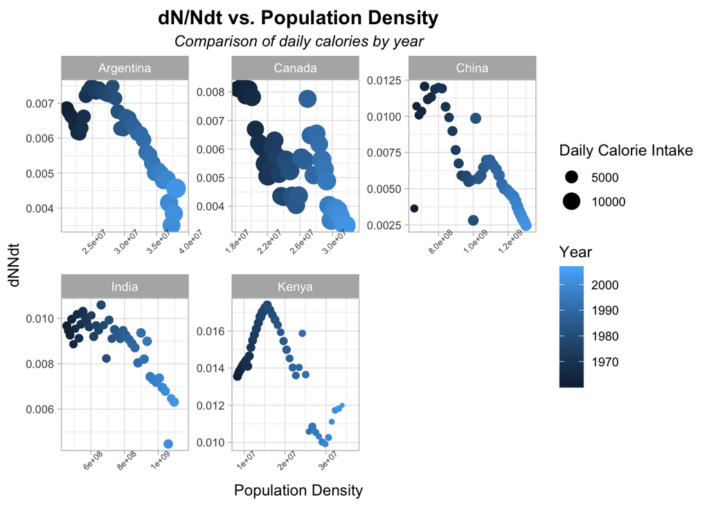

```r
# Extra Credit

extra_jitter <- ggplot(country_data, aes(x = population, y = dNNdt, size = calories_pd, color = year)) +
  geom_point() +
   theme_light() +
  theme(
    legend.position="right",
    plot.title = element_text(size=14)
  ) +
  theme(
    plot.title=element_text(hjust=0.5, vjust=0.5, face='bold'),
    plot.subtitle = element_text(hjust=0.5, vjust=0.5, face='italic')
  ) +
  theme(axis.text.x = element_text(
    angle = 45,
    size=6),
    axis.text.y = element_text(size=8)
  ) +
  labs(x = "Population Density",
       y = "dNNdt",
       title = "dN/Ndt vs. Population Density",
       subtitle = "Comparison of daily calories by year") +
  facet_wrap(~country, scales = "free") +
  labs(
         color = "Year",
         size = "Daily Calorie Intake"
        )

extra_jitter
```

```r
# In class we showed what the plot of dN/Ndt versus population density should look like. For each country

# 1, plot dN/Ndt vs Nt.

arg_china_pop <- country_data %>%
  dplyr::select(country, year, population, dNNdt) %>%
  filter(country == "Argentina" | country == "China")
```

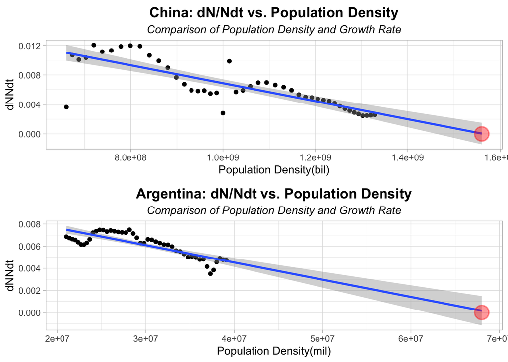

```r
china_pop <- arg_china_pop %>%
  filter(country == "China")

china_jitter <- ggplot(china_pop, aes(x = population, y = dNNdt)) +
  geom_point() +
  xlim(660993001, 1560000000) +
  stat_smooth(method = "lm", fullrange = TRUE) +
  annotate("pointrange", x = 1560000000, y = 0, xmin = 1500000000, xmax = 1600000000, ymin = 0, ymax = 0,colour = "red", size = 1.5, alpha=0.4) +
   theme_light() +
  theme(
    legend.position="right",
    plot.title = element_text(size=14)
  ) +
  theme(
    plot.title=element_text(hjust=0.5, vjust=0.5, face='bold'),
    plot.subtitle = element_text(hjust=0.5, vjust=0.5, face='italic')
  ) +
  labs(x = "Population Density(bil)",
       y = "dNNdt",
       title = "China: dN/Ndt vs. Population Density",
       subtitle = "Comparison of Population Density and Growth Rate")



arg_pop <- arg_china_pop %>%
  filter(country == "Argentina")

arg_jitter <- ggplot(arg_pop, aes(x = population, y = dNNdt)) +
  geom_point() +
  xlim(21021001, 68000000) +
  stat_smooth(method = "lm", fullrange = TRUE) +
  annotate("pointrange", x = 68000000, y = 0, xmin = 62000000, xmax = 70000000, ymin = 0, ymax = 0,colour = "red", size = 1.5, alpha=0.4) +
  theme_light() +
  theme(
    legend.position="right",
    plot.title = element_text(size=14)
  ) +
  theme(
    plot.title=element_text(hjust=0.5, vjust=0.5, face='bold'),
    plot.subtitle = element_text(hjust=0.5, vjust=0.5, face='italic')
  ) +
  labs(x = "Population Density(mil)",
       y = "dNNdt",
       title = "Argentina: dN/Ndt vs. Population Density",
       subtitle = "Comparison of Population Density and Growth Rate")

# I wanted to change the scale from sci-notation to basic numbers.  But was having a difficult time since I extended the scale.  However, this code DOES work. scale_x_continuous(breaks = c(2e+07, 3e+07, 4e+07, 5e+07, 6e+07), labels = c("20", "30", "40", "50", "60"))

grid.arrange(china_jitter, arg_jitter, nrow = 2)
```

#### As we briefly explored in class, there are many socioeconomic variables that can influence population growth. The data you received have some variables that might help you tease appart their effects.

##### a) Do a multiple linear regression of dN/Ndt on education and food for all five countries combined. (5 pts)

##### b) Do a multiple linear regression of dN/Ndt on any variables of your interest, for a country you chose. (5 pts) Show these results in a table3, and then discuss what your coefficients show and mean.

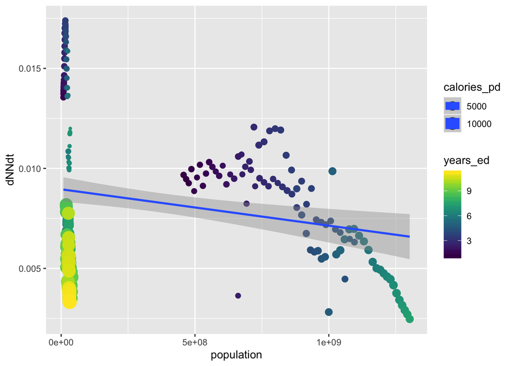

```r
country_roll <- country_data %>%
  group_by(year, country, calories_pd, years_ed) %>%
  drop_na()


calories_mlr <- lm(dNNdt ~ calories_pd, data = country_roll)

ed_mlr <- lm(dNNdt ~ years_ed, data = country_roll)

total_mlr <- lm(dNNdt ~ years_ed + calories_pd, data = country_roll)

# Is there an interactive effect of caloric intake on Growth Rate?

# AIC(calories_mlr)
# AIC(ed_mlr)


total_order_plot <- ggplot(country_roll, aes(x=population, y=dNNdt, size = calories_pd, color = years_ed)) +
  geom_point() +
  geom_smooth(method = "lm") +
  theme_gray() +
  scale_fill_viridis() +
  scale_color_viridis() +
  theme(
    legend.position="right",
    plot.title = element_text(size=14)
  ) +
  theme(
    plot.title=element_text( hjust=0.5, vjust=0.5, face='bold'),
    plot.subtitle = element_text(hjust=0.5, vjust=0.5, face='italic'))

total_order_plot
```

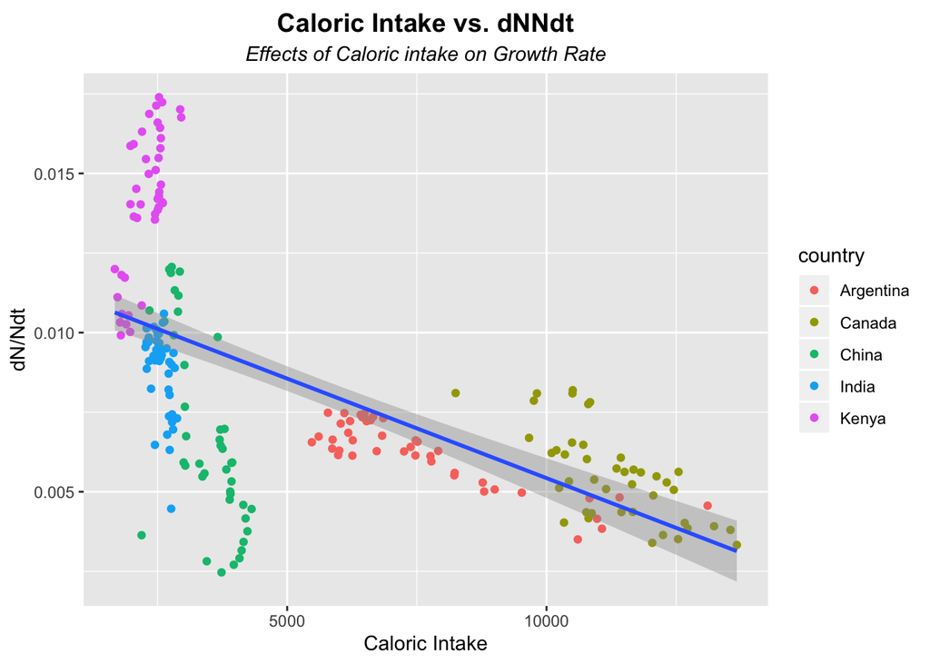

```r
calorie_order_plot <- ggplot(country_roll, aes(x=calories_pd, y=dNNdt)) +
  geom_point(aes(color = country)) +
  geom_smooth(method = "lm", scales = "free") +
  theme_gray() +
  theme(
    legend.position="right",
    plot.title = element_text(size=14)
  ) +
  theme(
    plot.title=element_text(hjust=0.5, vjust=0.5, face='bold'),
    plot.subtitle = element_text(hjust=0.5, vjust=0.5, face='italic')
  ) +
  labs(x = "Caloric Intake",
       y = "dN/Ndt",
       title = "Caloric Intake vs. dNNdt",
       subtitle = "Effects of Caloric intake on Growth Rate")

calorie_order_plot
```

```r
total_mlr <- lm(dNNdt ~ years_ed + calories_pd, data = country_roll)

stargazer(total_mlr, title="Results", align=TRUE, type = 'html')
```

**Results**

|  | *Dependent variable:* |
| --- | --- |
|  | dNNdt |
| years_ed | -0.0005*** |
|  | (0.0001) |
| calories_pd | -0.00000** |
|  | (0.00000) |
| Constant | 0.013*** |
|  | (0.0005) |
| Observations | 215 |
| R<sup>2</sup> | 0.419 |
| Adjusted R<sup>2</sup> | 0.414 |
| Residual Std. Error | 0.003 (df = 212) |
| F Statistic | 76.491*** (df = 2; 212) |
| *Note:* | p<0.1; p<0.05; p<0.01 |